Yu Dong En  
P1936348  
EP_0302_02  
**List of links of all datasets used:**  
Government Health Expenditure: https://data.gov.sg/dataset/government-health-expenditure,  
Number of Healthcare Specialists per 10,00 Total Population: [Deleted],  
Number of Pharmacists: https://data.gov.sg/dataset/number-of-pharmacists,  
Health Facilities: https://data.gov.sg/dataset/health-facilities,  
Dengue Incidence Rate:https://data.gov.sg/dataset/vector-control-data-dengue-outbreak-statistics,  
Weekly Dengue Cases: https://data.gov.sg/dataset/weekly-number-of-dengue-and-dengue-haemorrhagic-fever-cases,  
Medisave accounts and balances: https://data.gov.sg/dataset/medisave-accounts-and-balances-annual

# 1. Healthcare expenditure, and meeting increasing demand.

Healthcare is a problem for every nation. This is becoming an increasingly discussed issue especially with the coronavirus outbreak. Singapore, being one of the countries with the lowest birthrate, has an aging population which require more health facilities to accomodate the increasing demand. In the bottom few cells, we are going to explore what the government has done to increase its healthcare capacity and answer questions like:  
-How big is the impact of government funding on the amount of government facilities available to use?  
-How will government funding impacted Employment for Nurses and Doctors?  
-How does Government Funding impact the number of Public sector pharmacists in comparision to Private sector pharmacist?

```python
import pandas as pd
import numpy as np
import matplotlib.pyplot as plt

df_dataset1 = pd.read_csv('number-of-pharmacists.csv').set_index('year')
df_dataset2 = pd.read_csv('medical-practitioner-per-10-000-total-population.csv').set_index('year')
df_dataset3 = pd.read_csv('government-health-expenditure.csv').set_index('financial_year')
df_dataset4 = pd.read_csv('health-facilities-and-beds-in-inpatient-facilities-public-not-for-profit-private.csv').set_index('year')

display(df_dataset1)
display(df_dataset2)
display(df_dataset3)
display(df_dataset4)
```

| year | sector | count |
| --- | --- | --- |
| 2006 | Public Sector | 449 |
| 2006 | Private Sector | 832 |
| 2006 | Not in Active Practice | 140 |
| 2007 | Public Sector | 484 |
| 2007 | Private Sector | 865 |
| 2007 | Not in Active Practice | 134 |
| 2008 | Public Sector | 555 |
| 2008 | Private Sector | 858 |
| 2008 | Not in Active Practice | 133 |
| 2009 | Public Sector | 630 |
| 2009 | Private Sector | 890 |
| 2009 | Not in Active Practice | 138 |
| 2010 | Public Sector | 712 |
| 2010 | Private Sector | 931 |
| 2010 | Not in Active Practice | 171 |
| 2011 | Public Sector | 842 |
| 2011 | Private Sector | 978 |
| 2011 | Not in Active Practice | 193 |
| 2012 | Public Sector | 934 |
| 2012 | Private Sector | 1048 |
| 2012 | Not in Active Practice | 190 |
| 2013 | Public Sector | 1082 |
| 2013 | Private Sector | 1104 |
| 2013 | Not in Active Practice | 190 |
| 2014 | Public Sector | 1179 |
| 2014 | Private Sector | 1174 |
| 2014 | Not in Active Practice | 210 |
| 2015 | Public Sector | 1307 |
| 2015 | Private Sector | 1221 |
| 2015 | Not in Active Practice | 229 |
| 2016 | Public Sector | 1367 |
| 2016 | Private Sector | 1248 |
| 2016 | Not in Active Practice | 260 |
| 2017 | Public Sector | 1472 |
| 2017 | Private Sector | 1344 |
| 2017 | Not in Active Practice | 231 |
| 2018 | Public Sector | 1535 |
| 2018 | Private Sector | 1367 |
| 2018 | Not in Active Practice | 314 |
| 2019 | Public Sector | 1616 |
| 2019 | Private Sector | 1444 |
| 2019 | Not in Active Practice | 348 |

| year | level_1 | value |
| --- | --- | --- |
| 1960 | Doctors Per 10,000 Total Population | 4 |
| 1960 | Dentists Per 10,000 Total Population | 2 |
| 1960 | Nurses Per 10,000 Total Population | na |
| 1961 | Doctors Per 10,000 Total Population | 4 |
| 1961 | Dentists Per 10,000 Total Population | 2 |
| ... | ... | ... |
| 2018 | Dentists Per 10,000 Total Population | 4 |
| 2018 | Nurses Per 10,000 Total Population | 75 |
| 2019 | Doctors Per 10,000 Total Population | 25 |
| 2019 | Dentists Per 10,000 Total Population | 4 |
| 2019 | Nurses Per 10,000 Total Population | 75 |

180 rows × 2 columns

| financial_year | operating_expenditure | development_expenditure | government_health_expenditure | percentage_gdp |
| --- | --- | --- | --- | --- |
| 2006 | 1840 | 96 | 2009.7 | 0.9 |
| 2007 | 2019 | 185 | 2283.2 | 0.8 |
| 2008 | 2379 | 336 | 2814.1 | 1.0 |
| 2009 | 2920 | 711 | 3745.8 | 1.3 |
| 2010 | 3258 | 485 | 3856.7 | 1.2 |
| 2011 | 3489 | 453 | 4091.5 | 1.2 |
| 2012 | 4066 | 605 | 4837.3 | 1.3 |
| 2013 | 5044 | 723 | 5938.1 | 1.6 |
| 2014 | 5872 | 1147 | 7223.1 | 1.8 |
| 2015 | 7520 | 1413 | 8639.9 | 2.1 |
| 2016 | 8199 | 1618 | 9307.0 | 2.1 |
| 2017 | 8734 | 1465 | 9764.3 | 2.1 |

| year | institution_type | facility_type_a | public_private | no_of_facilities | no_beds |
| --- | --- | --- | --- | --- | --- |
| 2009 | Hospital | Acute | Public | 7 | 6416 |
| 2009 | Hospital | Acute | Not-for-Profit | 1 | 303 |
| 2009 | Hospital | Acute | Private | 6 | 1570 |
| 2009 | Hospital | Psychiatric Hospitals | Public | 1 | 2040 |
| 2009 | Hospital | Psychiatric Hospitals | Not-for-Profit | 0 | 0 |
| ... | ... | ... | ... | ... | ... |
| 2019 | Residential Long-Term | Nursing Homes | Not-for-Profit | 23 | 5963 |
| 2019 | Residential Long-Term | Nursing Homes | Private | 31 | 3858 |
| 2019 | Residential Long-Term | Inpatient Hospices | Public | 0 | 24 |
| 2019 | Residential Long-Term | Inpatient Hospices | Not-for-Profit | 2 | 155 |
| 2019 | Residential Long-Term | Inpatient Hospices | Private | 0 | 0 |

165 rows × 5 columns

# 2.The Datasets used in detail and issues

Datasets: Government Health Expenditure: https://data.gov.sg/dataset/government-health-expenditure,  
Number of Healthcare Specialists per 10,00 Total Population: Deleted,  
Number of Pharmacists: https://data.gov.sg/dataset/number-of-pharmacists,  
Health Facilities: https://data.gov.sg/dataset/health-facilities .

The Number of Healthcare Specialists per 10,00 Total Population Dataaset has an issue where some of the "Nurses" data in the column "Healthcare specialists per 10,00 people" is missing and has been replaced with the string "na". This causes the whole column to be a String. I had to replace 'na' with -1 and change the whole column to be integers.

The Health Facilities Dataset has 3 types of Healthcare Facilities, Private , Not-for-Profit , Public. In this Notebook, I will assume only Public Healthcare facilities are funded by the government as i could not find out if Not-for-Profit Healthcare Facilities were government funded.

The context here is that the Government has stated that they are allocating more money to make healthcare more affordable(Refer to source linked). This will be achieved by building more infrastructure, and hiring more healthcare workers. These will be covered in the Health Facilities Dataset , The Number of Healthcare Specialists per 10,000 Total Population Dataset and The Number of Pharmacists Dataset respectively.

Government Health Expenditure Dataset will be used to review the Government's increased Allocation of Money and GDP.

Source: https://www.mof.gov.sg/singapore-budget/curated-budget-reads/injecting-more-into-singapore-s-healthcare-as-we-age

# 3.The Government Health Expenditure Dataset

Lets start by looking at the Government's healthcare expenditures per year since 2006 to 2017 and the percentage of GDP it consists of.  
As stated above, Government Health Expenditure Dataset will be used to review the Government's increased Allocation of Money and GDP.

[output not shown]

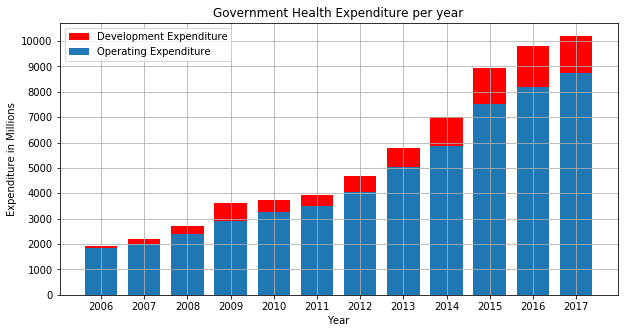

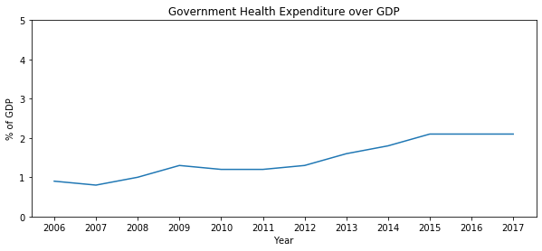

```python
import pandas as pd
import numpy as np
import matplotlib.pyplot as plt

def sort_func1(dataset,location):
   return dataset.loc[:,location]

#Setting Dataset
df_GovHealthexpenditureDataset = pd.read_csv('government-health-expenditure.csv').set_index('financial_year')

#Sorting
df_GovHealthexpenditureDataset_oe = sort_func1(df_GovHealthexpenditureDataset,"operating_expenditure")
df_GovHealthexpenditureDataset_de = sort_func1(df_GovHealthexpenditureDataset,"development_expenditure")
df_GovHealthexpenditureDataset_pc = sort_func1(df_GovHealthexpenditureDataset,"percentage_gdp")

#Graph 1 Plotting
plt.figure(figsize=(10, 5))
plt.bar(np.arange(2006,2018,1), df_GovHealthexpenditureDataset_de,align='center',color='red', alpha=1,width=.75,label="Development Expenditure",bottom=df_GovHealthexpenditureDataset_oe)
plt.bar(np.arange(2006,2018,1), df_GovHealthexpenditureDataset_oe,align='center',alpha=1, width=.75,label="Operating Expenditure")

#Graph 1 Setting
plt.xticks(np.arange(2006,2018,1))
plt.yticks(np.arange(0,11000,1000))
bar_width = 0.6
plt.xlabel("Year")
plt.ylabel("Expenditure in Millions")
plt.title('Government Health Expenditure per year')
plt.legend(loc='best')
plt.grid()
plt.show()

#Graph 2 Plotting
fig, ax = plt.subplots()
fig.set_figwidth(10)
ax.plot(np.arange(2006,2018,1),df_GovHealthexpenditureDataset_pc)

#Graph 2 Setting
ax.set_title('Government Health Expenditure over GDP')
plt.xlabel("Year")
plt.ylabel("% of GDP")
plt.yticks(np.arange(0,6,1))
plt.xticks(np.arange(2006,2018,1))
plt.show()
```

# 4.The Government Health Expenditure Dataset in detail

Due to the nature of plotting the bar graph, a for-loop could not be used to plot.  
So first, I sorted the Dataset by the type of Expenditure.  
Then I used the operating expenditure and the developmental expenditure to plot the bar graph.  
I used the percentage expenditure to plot the line graph.  
I also used the bottom attribute in the bar graph to add the Developmental Expenditure to the Operating Expenditure to make the bar a 100% of the Government Health Expenditure, so that it would be easier to visualize.  
**Lets start by looking at the Graph 1.**  
At the first bar, 2006, there is little Development expenditure compared to Operating Expenditure.  
However, during the 2007-2009 period, there is a increasing trend of more Development Expenditure, climaxing in the 2009 bar, in which its Developmental Expenditure is significantly more than the previous years.  
In 2011, 2012, the trend seems to stagnate.  
In 2013, the trend starts again. From 2014 to 2017, the increase in Developmental Expenditure is very significant and amounts to approximately 1500 Million dollars.  
Regarding Operating Expenditure, it increases every year incrementally. This may be due to new Developments as the Operating Expenditure mirrors the previous year's Total Expenditure.  
Regarding Total Expenditure, it mirrors the Operating Expenditure's Growth.  
**Now lets look at Graph 2.**  
Overall, the Graph shows the GDP expenditure more than doubling.  
In 2006-2009, the amount first decreases, then increases again after 2007.  
In 2010-2012, the amount stagnates and remains roughly the same.  
In 2013-2015, the amount sharply increases, reaching the 2% marker.  
Finally, in 2015-2017, the amount stagnates and stays above more than 2%.  
**Overall**  
The Government has increased the amount of money and the percentage of GDP used for Healthcare from 2006 to 2017.  
The majority of money spent is spent on Operating costs and the rest are spent on Developmental Costs, these increased throughout the years.  
The main focus is Developmental costs as the Government stated they wanted to improve healthcare affordability, by **expanding** infrastructure.  
Comparing 2006 to 2017, Developmental costs have increased massively. From less than 100 Million to more than 1 Billion.  
The GDP used has doubled from 2006 to 2017.

# 5.The Number of Healthcare Specialists per 10,00 Total Population Dataset

Now that we have seen how much the government spends on Healthcare, its breakdown and the trends, we should see how this affects the amount of public healthcare specialists, namely Doctors,Nurses and Dentists.

As stated above, Number of Healthcare Specialists per 10,00 Total Population Dataset, which has some missing infomation as stated above,will be used to review the amount of public healthcare specialists.

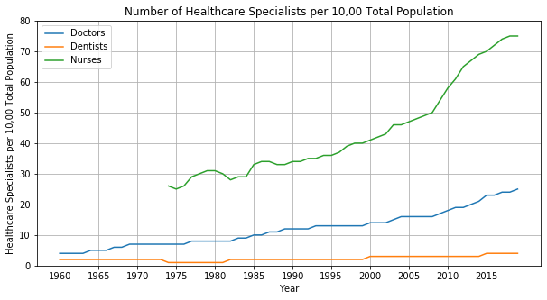

```python
import pandas as pd
import numpy as np
import matplotlib.pyplot as plt

def sort_func2(dataset1,dataset2,string):
   return dataset1[dataset2 == string]

#Setting Dataset
df_HealthcareSpecialists = pd.read_csv('medical-practitioner-per-10-000-total-population.csv').set_index('year')

#Replace NA values with a -1 integer, this will be explained later.
df_HealthcareSpecialists_1 = df_HealthcareSpecialists.loc[:,'level_1']
df_HealthcareSpecialists.replace("na","-1",inplace=True)
df_HealthcareSpecialists.loc[:,'value'] = df_HealthcareSpecialists.loc[:,'value'].astype(int)

#Sorting
df_HealthcareSpecialists_dr = sort_func2(df_HealthcareSpecialists,df_HealthcareSpecialists_1,'Doctors Per 10,000 Total Population')
df_HealthcareSpecialists_de = sort_func2(df_HealthcareSpecialists,df_HealthcareSpecialists_1,'Dentists Per 10,000 Total Population')
df_HealthcareSpecialists_nur = df_HealthcareSpecialists[np.logical_and(df_HealthcareSpecialists_1 == 'Nurses Per 10,000 Total Population',df_HealthcareSpecialists.loc[:,'value'] != -1)]

#Graph 1 Plotting
plt.figure(figsize=(10, 5))
plt.plot(df_HealthcareSpecialists_dr.index, 'value', data=df_HealthcareSpecialists_dr, linewidth=1.5,label='Doctors')
plt.plot(df_HealthcareSpecialists_de.index, 'value', data=df_HealthcareSpecialists_de, linewidth=1.5,label='Dentists')
plt.plot(df_HealthcareSpecialists_nur.index, 'value', data=df_HealthcareSpecialists_nur, linewidth=1.5,label='Nurses')

#Graph 1 Setting
plt.grid()
plt.yticks(np.arange(0,90,10))
plt.xticks(np.arange(1960,2019,5))
plt.ylim(min(np.arange(0,70,5)))
plt.xlabel("Year")
plt.ylabel("Healthcare Specialists per 10,00 Total Population")
plt.title('Number of Healthcare Specialists per 10,00 Total Population')
plt.legend()
plt.show()
```

# 6.The Number of Healthcare Specialists per 10,00 Total Population Dataset in detail

**Overall**  
Overall, The Amount of Nurses increases gradually until 2008, where it experiences a large rate of increase.  
The Amount of Doctors increases gradually until 2008, where it experiences a high rate of increase, however, it is not as large as the Nurse's increase.  
The reason for the large 2008-2009 increase is probably due to the high Developmental Expenditure in the year 2008-2009 (Refer to Dataset and Graph 1).  
The Amount of Dentist's increases gradually over the years.

# 7.The Number of Pharmacists Dataset

Number of Pharmacists Dataset is about the types of Pharmacists and the amount of them.  
Public Sector Pharmacists are Government Healthcare Workers while Private Sector Pharmacists are not.  
For this Dataset, I will ignore the "Not in Active Practice" as they are irrelavant.

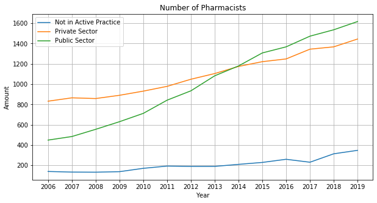

```python
import pandas as pd
import numpy as np
import matplotlib.pyplot as plt

#Setting Dataset
df_NumberPharmacists= pd.read_csv('number-of-pharmacists.csv').set_index('year')

#Sort by year, ascending
df_NumberPharmacists_sorted = df_NumberPharmacists.sort_values(by='year',ascending=True)

#Graph 1 Plotting and Sorting
plt.figure(figsize=(10, 5))
for label in np.unique(df_NumberPharmacists_sorted.iloc[:,0].to_numpy()):
    plt.plot( df_NumberPharmacists_sorted[df_NumberPharmacists_sorted.iloc[:,0] == label].index, 'count', data=df_NumberPharmacists_sorted[df_NumberPharmacists_sorted.iloc[:,0] == label],linewidth=1.5,label=label)

#Graph 1 Setting
plt.xticks(np.arange(2006,2020,1))
plt.title('Number of Pharmacists')
plt.xlabel("Year")
plt.ylabel("Amount")
plt.legend()
plt.grid()
plt.show()
```

# 8.The Number of Pharmacists Dataset in detail

For this Dataset, I sorted the Dataset by year and ascending using the .sort_values. function  
I then used a for loop to iterate over every unique type of phamacist.  
I controlled this array by using the np.unique function to get every unique value of every element in the array.  
The for-loop plots the graph for every instance.

In 2006, there are 449 Public Sector Pharmacists and 832 Private Sector Pharmacists.  
The number of Private Sector Pharmacists from 2006 to 2008 stagnates at around 850.  
The number then increases at a steady rate, being surpassed by the number of Public Sector Pharmacists in the 2013-2014 period, then increasing to 1444 at 2019.  
The number of Public Sector Pharmacists increases at a steady rate from 2006 to 2010. After 2010, the rate of increase is greater and eventually, in the 2013-2014 period, it surpasses the number of Private Sector Pharmacists.  
It then continues its rate of increase until 2019, where it reaches 1616.

**Overall**  
The number of Private Sector Pharmacists are higher at the start compared to the number of Public Sector Pharmacists.  
However, the number of Public Sector Pharmacists past 2009 experiences a higher rate of increase than the Private Sector Pharmacists, leading to the number of Public Sector Pharmacists being higher than Private Sector by 2014 and ending the graph with 172 more Public Sector Pharmacists.  
This could be due to the Government's increased funding on Developmental Expenditure from 2008 onwards, more facilities would mean more staff being paid to staff them.  
This would also lead to higher Operating Expenditure in the following years, which also happens in the Government Health Expenditure Dataset.

# 9. The Health Facilities Dataset

The Health Facilities Dataset is about the number of Facilities and the number of beds they provide.  
The Health Facilities Dataset has 3 types of Healthcare Facilities, Private , Not-for-Profit , Public.  
In this Dataset, I will assume only Public Healthcare facilities are funded by the government as i could not find out if Not-for-Profit Healthcare Facilities were government funded.  
An Acute Care Facility is a facility where a patient receives active but short-term treatment for a severe injury or episode of illness.

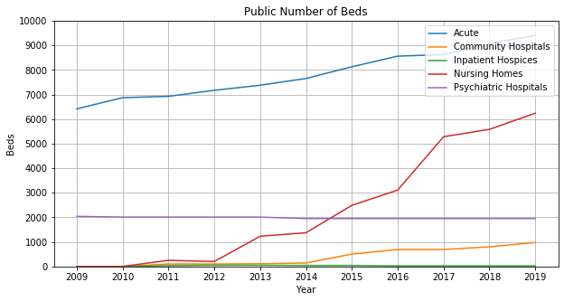

```python
import pandas as pd
import numpy as np
import matplotlib.pyplot as plt
import matplotlib.cm as cm

#Setting Dataset
df_HealthFacilities = pd.read_csv('health-facilities-and-beds-in-inpatient-facilities-public-not-for-profit-private.csv').set_index('year')

#Sorting only government/public facilities
df_HealthFacilities = df_HealthFacilities[df_HealthFacilities.loc[:,'public_private'] == "Public"]

#Graph 1 Sorting and Plotting
plt.figure(figsize=(10, 5))
for label in np.unique(df_HealthFacilities.loc[:,'facility_type_a'].to_numpy()):
    plt.plot(df_HealthFacilities[df_HealthFacilities.loc[:,'facility_type_a'] == label].loc[:,'no_beds'].index,df_HealthFacilities[df_HealthFacilities.loc[:,'facility_type_a'] == label].loc[:,'no_beds'],label=label)


#Graph 1 Setting
plt.title('Public Number of Beds')
plt.xlabel("Year")
plt.ylabel("Beds")
plt.ylim(-1)
plt.yticks(np.arange(0,11000,1000))
plt.xticks(np.arange(2009,2020,1))
plt.legend(loc='upper right')#Could make best but it looks weird
plt.grid()
plt.show()
```

# 10.The Health Facilities Dataset in detail

To sort the data, I first sorted everything to include only public facilities.  
I then get every unique type of facility into a numpy array then iterate through each element using a for-loop.  
I use this for loop to plot each line.

The number of Beds for Acute Care have increased. The Acute Care in 2009 provided 6500 beds, and increases throughout the years to a maximum of 9404 beds in 2019. The rate of increase is steady and relatively constant throughout the years.  
The number of beds in nursing homes was 0 until 2010, this has increased to 250 by 2011.  
The number then stagnates until 2013, where it increases sharply.  
It then continued to increase at this rate until 2017, where the rate stagnates and increases slower.  
The maximum number is at 6238 in 2019.  
There were no beds in Community Hospitals until 2010.  
In 2011, 100 beds where added. From 2011 to 2014, there is no increase.  
From 2014-2016, there is a relatively large increase.  
From 2016 to 2017, there is little to no increase.  
From 2017 to 2019, there is a slight increase. The maximum number of beds in Community Hospitals is 974 in 2019.  
**Overall**  
There is no obvious standout trend which cannot be confirmed by other datasets for the number of beds in Public Acute Care facilities. The steady increase in beds can be explained by new facilties or reassignment of wards.  
However, the increase is not substantial enough to suggest the government is putting much focus on it. There were no Public Nursing Homes in 2009, and in 2019 there are 6238 beds.  
This is a very large increase in the number of beds.  
There were no beds in community hospitals in 2009. And until 2014, there were only 100 beds in community hospitals.  
However in 2019, there were 974.  
This is a very large increase in the number of beds..  
Both of these large increases could be due to the Government's increased funding on Developmental Expenditure from 2008 onwards.  
The large increases do not exactly correlate with the Government's large increase in funding in 2009,  
as their large increases were in 2012 and 2014 respectively.  
This could be due to their facilities taking time to be constructed or other factors such as their construction was not due to the 2009 increase in funding  
and was due to a later increase.

# 11. Conclusions

**How does Government Funding impact the number of Public Sector Pharmacists in comparision to Private Sector Pharmacist?**  
At the start, the number of Public Sector Pharmacists is lower than Private Sector Pharmacists.  
At the end, the number of Public Sector Pharmacists is much larger than the Private Sector Pharmacists.  
The rate of gain for Public Sector Pharmacists from the start was higher than the Private Sector Pharmacists, leading to the number of Public Sector Pharmacists being higher than Private Sector in the period between 2013-2014.  
However, there is no large increase when there was a large increase in Developmental Funding in 2009 and 2014 respectively. The gain remains steady even in years when there was little to none Developmental Expenditure.  
There is not enough evidence that Government Funding has a large increase in the number of Pharmacists, and thus we can conclude that Government Funding does not have a large impact on the number of Public Sector Pharmacists in comparision to Private Sector Pharmacist.